# Psych 254 W15 PS #3

Robert Hawkins

March 20, 2015

This is problem set #3, in which we want you to integrate your knowledge of data wrangling with some basic simulation skills and some linear modeling.

```r
library(dplyr)
```

```r
library(ggplot2)
```

# Part 1: Basic simulation and NHST

Let’s start by convincing ourselves that t-tests have the appropriate false positive rate. Run 10,000 t-tests with standard, normally-distributed data from a made up 30-person, single-measurement experiment (the command for sampling from a normal distribution is `rnorm`). What’s the mean number of “significant” results?

First do this using a `for` loop.

```r
sigCount = 0
numSamples = 10000
for(i in 1:numSamples) {
  fakeSample = rnorm(30)
  stat = t.test(fakeSample)
  if(stat$p.value < 0.05) {
    sigCount = sigCount + 1;
  }
}
print(sigCount / numSamples)
```

```
## [1] 0.0559
```

Next, do this using the `replicate` function:

```r
numSamples = 10000
testRes <- replicate(numSamples, t.test(rnorm(30))$p.value < .05)
cat("false positive rate:", sum(testRes)/numSamples)
```

```
## false positive rate: 0.0493
```

**Using both methods, we find a false positive rate of about 0.05! In other words, if the null hypothesis is true and there is no effect, we’ll still report one about 5% of the time. This is our alpha value (in decision-theoretic terms). As the number of samples increases, we’ll converge to this rate exactly.**

Ok, that was a bit boring. Let’s try something moderately more interesting - let’s implement a p-value sniffing simulation, in the style of Simons, Nelson, & Simonsohn (2011).

Consider this scenario: you have done an experiment, again with 30 participants (one observation each, just for simplicity). The question is whether their performance is above chance. You aren’t going to check the p-value every trial, but let’s say you run 30 - then if the p-value is within the range p < .25 and p > .05, you optionally run 30 more and add those data, then test again. But if the original p value is < .05, you call it a day, and if the original is > .25, you also stop.

First, write a function that implements this sampling regime.

```r
double.sample <- function (maxP) {
  fakeSample1 = rnorm(30)
  test1p = t.test(fakeSample1)$p.value
  if(test1p >= maxP || test1p < .05) {
    return (test1p < 0.05)
  } else {
    fakeSample2 = rnorm(30)
    test2p = t.test(c(fakeSample1, fakeSample2))$p.value
    return (test2p < 0.05)
  }
}
```

Now call this function 10k times and find out what happens.

```r
numSamples = 10000
sum(replicate(numSamples, double.sample(.25)))/numSamples
```

```
## [1] 0.0723
```

Is there an inflation of false positives? How bad is it?

**There is indeed an inflation of false positives: we find false positives about 7% of the times instead of 5% as before**

Now modify this code so that you can investigate this “double the sample” rule in a bit more depth. Let’s see what happens when you double the sample ANY time p > .05 (not just when p < .25), or when you do it only if p < .5 or < .75. How do these choices affect the false positive rate?

HINT: Try to do this by making the function `double.sample` take the upper p value as an argument, so that you can pass this through dplyr.

HINT 2: You may need more samples. Find out by looking at how the results change from run to run.

```r
numSamples = 10000
d <- data.frame(caps = c(.05, .25, .5, .75, 1)) %>%
  group_by(caps) %>%
  mutate(falseAlarm = sum(replicate(numSamples, double.sample(caps)))/numSamples)
d
```

```
## Source: local data frame [5 x 2]
## Groups: caps
##
##   caps falseAlarm
## 1 0.05     0.0518
## 2 0.25     0.0711
## 3 0.50     0.0795
## 4 0.75     0.0818
## 5 1.00     0.0812
```

What do you conclude on the basis of this simulation? How bad is this kind of data-dependent policy?

# Part 2: The Linear Model

## 2A: Basic Linear Modeling

Let’s use the `ToothGrowth` dataset, on guineapig teeth based on orange juice and vitamin C. This is super simple. (Try `?ToothGrowth`).

First plot the data, we’ll use `qplot` to understand how `len` (tooth length) depends on `dose` (amount of Vitamin C) and `supp` (delivery method).

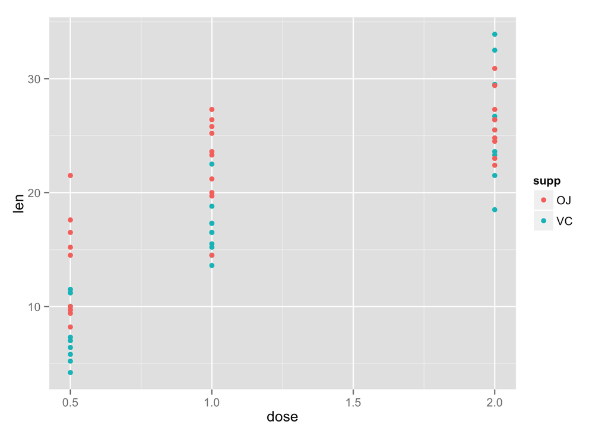

```r
data(ToothGrowth)
qplot(y = len, x = dose, color = supp, data = ToothGrowth)
```

So now you see what’s going on.

Next, always make a histogram of the DV before making a linear model! This reveals the distribution and can be helpful in choosing your model type.

```
## stat_bin: binwidth defaulted to range/30. Use 'binwidth = x' to adjust this.
```

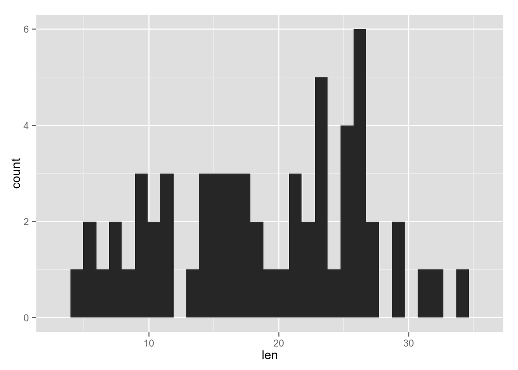

```r
qplot(len, data = ToothGrowth)
```

** We see that length has a rather wide distribution, possibly multimodal. It is likely a mixture of different distributions, which we can investigate in our linear model.**

Now make a linear model of tooth lengths using `lm`. Try making one with main effects and interactions and another with just main effects. Make sure to assign them to variables so that you can get them later.

```r
mainEffectModel <- lm(len ~ dose + supp, data = ToothGrowth)
summary(mainEffectModel)
```

```
##
## Call:
## lm(formula = len ~ dose + supp, data = ToothGrowth)
##
## Residuals:
##    Min     1Q Median     3Q    Max
## -6.600 -3.700  0.373  2.116  8.800
##
## Coefficients:
##             Estimate Std. Error t value Pr(>|t|)
## (Intercept)   9.2725     1.2824   7.231 1.31e-09 ***
## dose          9.7636     0.8768  11.135 6.31e-16 ***
## suppVC       -3.7000     1.0936  -3.383   0.0013 **
## ---
## Signif. codes:  0 '***' 0.001 '**' 0.01 '*' 0.05 '.' 0.1 ' ' 1
##
## Residual standard error: 4.236 on 57 degrees of freedom
## Multiple R-squared:  0.7038, Adjusted R-squared:  0.6934
## F-statistic: 67.72 on 2 and 57 DF,  p-value: 8.716e-16
```

```r
interactionModel <- lm(len ~ dose * supp, data = ToothGrowth)
summary(interactionModel)
```

```
##
## Call:
## lm(formula = len ~ dose * supp, data = ToothGrowth)
##
## Residuals:
##     Min      1Q  Median      3Q     Max
## -8.2264 -2.8462  0.0504  2.2893  7.9386
##
## Coefficients:
##             Estimate Std. Error t value Pr(>|t|)
## (Intercept)   11.550      1.581   7.304 1.09e-09 ***
## dose           7.811      1.195   6.534 2.03e-08 ***
## suppVC        -8.255      2.236  -3.691 0.000507 ***
## dose:suppVC    3.904      1.691   2.309 0.024631 *
## ---
## Signif. codes:  0 '***' 0.001 '**' 0.01 '*' 0.05 '.' 0.1 ' ' 1
##
## Residual standard error: 4.083 on 56 degrees of freedom
## Multiple R-squared:  0.7296, Adjusted R-squared:  0.7151
## F-statistic: 50.36 on 3 and 56 DF,  p-value: 6.521e-16
```

```r
anova(mainEffectModel, interactionModel, test="Chisq")
```

```
## Analysis of Variance Table
##
## Model 1: len ~ dose + supp
## Model 2: len ~ dose * supp
##   Res.Df     RSS Df Sum of Sq Pr(>Chi)
## 1     57 1022.56
## 2     56  933.63  1     88.92  0.02092 *
## ---
## Signif. codes:  0 '***' 0.001 '**' 0.01 '*' 0.05 '.' 0.1 ' ' 1
```

**We see that both dose and supplement are significant in the main effects model, and that the interaction between them is significant in the interactive model.**

Now try taking out the intercept, using a -1 term in the formula. what does this do?

```r
mainEffectModel <- lm(len ~ -1 + dose + supp, data = ToothGrowth)
summary(mainEffectModel)
```

```
##
## Call:
## lm(formula = len ~ -1 + dose + supp, data = ToothGrowth)
##
## Residuals:
##    Min     1Q Median     3Q    Max
## -6.600 -3.700  0.373  2.116  8.800
##
## Coefficients:
##        Estimate Std. Error t value Pr(>|t|)
## dose     9.7636     0.8768  11.135 6.31e-16 ***
## suppOJ   9.2725     1.2824   7.231 1.31e-09 ***
## suppVC   5.5725     1.2824   4.345 5.79e-05 ***
## ---
## Signif. codes:  0 '***' 0.001 '**' 0.01 '*' 0.05 '.' 0.1 ' ' 1
##
## Residual standard error: 4.236 on 57 degrees of freedom
## Multiple R-squared:  0.9586, Adjusted R-squared:  0.9564
## F-statistic: 439.7 on 3 and 57 DF,  p-value: < 2.2e-16
```

```r
interactionModel <- lm(len ~ -1 + dose * supp, data = ToothGrowth)
summary(interactionModel)
```

```
##
## Call:
## lm(formula = len ~ -1 + dose * supp, data = ToothGrowth)
##
## Residuals:
##     Min      1Q  Median      3Q     Max
## -8.2264 -2.8462  0.0504  2.2893  7.9386
##
## Coefficients:
##             Estimate Std. Error t value Pr(>|t|)
## dose           7.811      1.195   6.534 2.03e-08 ***
## suppOJ        11.550      1.581   7.304 1.09e-09 ***
## suppVC         3.295      1.581   2.084   0.0418 *
## dose:suppVC    3.904      1.691   2.309   0.0246 *
## ---
## Signif. codes:  0 '***' 0.001 '**' 0.01 '*' 0.05 '.' 0.1 ' ' 1
##
## Residual standard error: 4.083 on 56 degrees of freedom
## Multiple R-squared:  0.9622, Adjusted R-squared:  0.9595
## F-statistic: 356.2 on 4 and 56 DF,  p-value: < 2.2e-16
```

**This did not affect the interaction coefficient, but it added a level of the supplement factor**

HINT: use the `predict` function …

HINT 2: you will have to make a dataframe to do the prediction with, so use something like `data.frame(dose=...)`.

```r
newD = data.frame(dose=rep(c(0,1.5,2.5,10),2), supp = c(rep('OJ', 4), rep('VC', 4)))
newD
```

```
##   dose supp
## 1  0.0   OJ
## 2  1.5   OJ
## 3  2.5   OJ
## 4 10.0   OJ
## 5  0.0   VC
## 6  1.5   VC
## 7  2.5   VC
## 8 10.0   VC
```

```r
newD$predictions = predict(interactionModel, newD)
newD
```

```
##   dose supp predictions
## 1  0.0   OJ    11.55000
## 2  1.5   OJ    23.26714
## 3  2.5   OJ    31.07857
## 4 10.0   OJ    89.66429
## 5  0.0   VC     3.29500
## 6  1.5   VC    20.86857
## 7  2.5   VC    32.58429
## 8 10.0   VC   120.45214
```

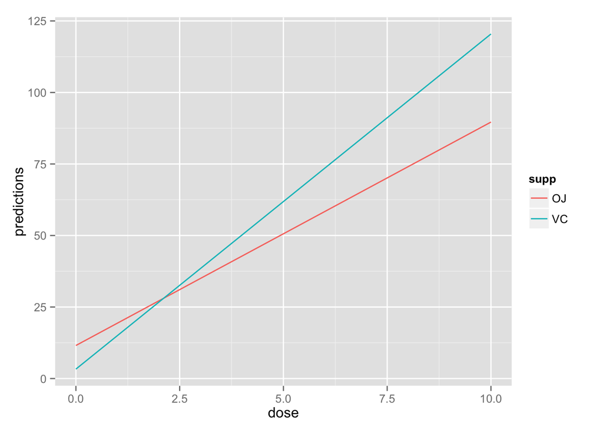

```r
ggplot(newD, aes(x = dose, y = predictions, color = supp)) + geom_line()
```

Now plot the residuals from the original model. How do they look? HINT: `?resid`

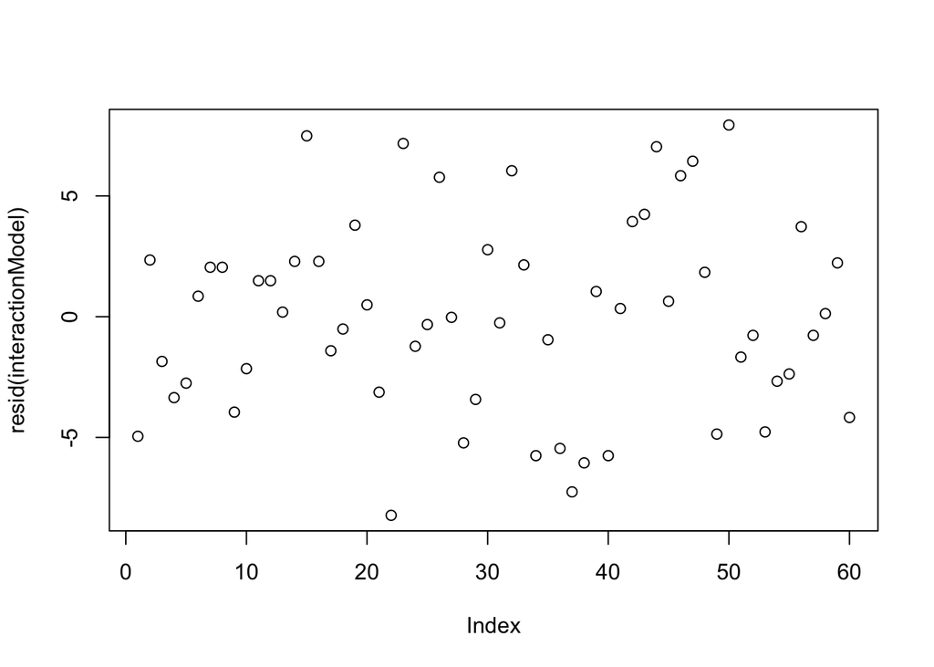

```r
plot(resid(interactionModel))
```

**Not bad! No clear trends, but also quite a bit of variability**

BONUS: test them for normality of distribution using a quantile-quantile plot.

HINT: `?qqplot` and `?qqnorm`

## 2B: Exploratory Linear Modeling

What the heck is going on? Load data from Frank, Vul, Saxe (2011, Infancy), a study in which we measured infants’ looking to hands in moving scenes. There were infants from 3 months all the way to about two years, and there were two movie conditions (`Faces_Medium`, in which kids played on a white background, and `Faces_Plus`, in which the backgrounds were more complex and the people in the videos were both kids and adults). Forgive our bad naming conventions.

Try to figure out what the most reasonable linear model of the data is.

```r
d <- read.csv("../data/FVS2011-hands.csv")
```

Plot that model on the same plot as the data.

HINT: you can do this either using `predict` or (if you are feeling confident of your understanding of the models) using the built-in linear models in `ggplot`’s `geom_smooth`.

What do you conclude from this pattern of data?

# 3: Linear Mixed Effect Models

The goal here is to learn to use LMEMs using `lme4` and to compare them to standard by subject, by item LMs, as well as the standard (no repeated measures) fixed effects GLM.

The dataset here is from Stiller, Goodman, & Frank (2014), a paper on children’s pragmatic inferences. We saw the paradigm in the counterbalancing lecture: it’s three faces: a smiley, a smiley with glasses, and a smiley with a hat and glasses. When told “my friend has glasses” do kids pick the one with the glasses and no hat? `age.group` is the kids’ age group, `condition` is either “label,” described above, or “no label,” which was a control condition in which kids picked without hearing the term “glasses” at all.

```r
d <- read.csv("../data/scales.csv")
d$age.group <- factor(d$age.group)
```

Always begin with a histogram!

## Brief Confidence Interval Digression

Start out by setting up a function for a 95% CI using the normal approximation.

```r
ci95.norm <- function(x) {
}
```

But the number of participants in a group is likely to be < 30, so let’s also compute this with a t distribution.

```r
ci95.t <- function(x) {
}
```

On the other hand, maybe we should use bootstrap CIs because these are actually proportions, and the normal/t approximations don’t know that they are 0/1 bounded.

```r
library(boot)
library(bootstrap)
```

Take a look at `?boot` and `?bootci`. Note that the syntax for the `boot` library is terrible, so we’re going to use it to check some code that I use:

```r
theta <- function(x,xdata,na.rm=T) {mean(xdata[x],na.rm=na.rm)}
ci.low <- function(x,na.rm=T) {
  mean(x,na.rm=na.rm) -
    quantile(bootstrap(1:length(x),
                       10000,theta,x,na.rm=na.rm)$thetastar,.025,na.rm=na.rm)}
ci.high <- function(x,na.rm=T) {
  quantile(bootstrap(1:length(x),
                     10000,theta,x,na.rm=na.rm)$thetastar,.975,na.rm=na.rm) -
    mean(x,na.rm=na.rm)}
```

Now make 95% confidence intervals across participants using all the methods above:

- Normal
- t
- Bootstrap percentile using `boot.ci`
- Bootstrap percentile using my code

Now plot the data by age and condition using `dplyr` and `ggplot2`. Plot some CIs on here - extra credit if you plot all of them and compare visually (you’ll need `position = position_dodge()` or some other way to offset them).

What do you conclude about confidence interval computation?

## Back to LMEMs

```r
library(lme4)
```

OK, now do a basic GLM over the entire data frame, using `age.group`, `condition`, and their interaction to predict correctness. (If we were focusing on developmental issues, I would ask you to think about how to model age here, but let’s treat it as three discrete groups for now).

NOTE: this model is not appropriate, because it assumes that each subject’s observations are independent from one another. It’s still fine to do the analysis, though: it can tell you a lot about the data and is easy and fast to fit, as long as you know that you can’t trust the p-values!

Let’s now use `dplyr` to get data frames for by-items (`msi`) and by-subjects (`mss`) analyses. `msi` should contain the mean ratings for every item and `mss` should contain the mean ratings for every subject.

Now do standard linear models on each of these.

NOTE: These are not strictly correct either because of the normal approximation on percent correct (model doesn’t know it’s 0 - 1 bounded and could give you standard error that goes above 1). Again, useful to do and see what happens.

Do ANOVA on these. Note that ANOVA doesn’t let you figure out what is going on with individual levels of age.

On to linear mixed effect models. Create the maximal random effects model a la Barr et al. (2013). Does it converge? If not, what will you do to make it converge? (The internet can be your friend here).

HINT: try simplifying your model to a “semi-maximal” model. Bonus: try using a different fitting procedure on the maximal model.

HINT: make sure that you consider which random effects are appropriate. Consider which observations are within/between subjects. E.g. having a random coefficient for age by subject doesn’t make sense, because each subject has only one age.

How do these coefficients compare with the independent coefficients linear model? What do you conclude?

Which random effects make the most difference? Find out using `ranef`. Plot the random effects for subject and item.

Make the minimal random effects model with just a subject intecept. How does this compare?

Get an estimate of the significance value for the coefficient on the `age*condition` interaction by using anova to compare between your semi-maximal model and the model without an intercept.